# 1 Background

As a statistical consultant working for a real estate investment firm, your task is to develop a model to predict the selling price of a given home in Ames, Iowa. Your employer hopes to use this information to help assess whether the asking price of a house is higher or lower than the true value of the house. If the home is undervalued, it may be a good investment for the firm.

# 2 Training Data and relevant packages

In order to better assess the quality of the model you will produce, the data have been randomly divided into three separate pieces: a training data set, a testing data set, and a validation data set. For now we will load the training data set, the others will be loaded and used later.

```r
load("ames_train.Rdata")
```

Use the code block below to load any necessary packages

```r
library(statsr)
library(dplyr)
library(BAS)
library(MASS)
library(ggplot2)
```

## 2.1 Part 1 - Exploratory Data Analysis (EDA)

When you first get your data, it’s very tempting to immediately begin fitting models and assessing how they perform. However, before you begin modeling, it’s absolutely essential to explore the structure of the data and the relationships between the variables in the data set.

Do a detailed EDA of the ames_train data set, to learn about the structure of the data and the relationships between the variables in the data set (refer to Introduction to Probability and Data, Week 2, for a reminder about EDA if needed). Your EDA should involve creating and reviewing many plots/graphs and considering the patterns and relationships you see.

After you have explored completely, submit the three graphs/plots that you found most informative during your EDA process, and briefly explain what you learned from each (why you found each informative).

NOTE: Write your written response to part 1 here. Delete this note before you submit your work.

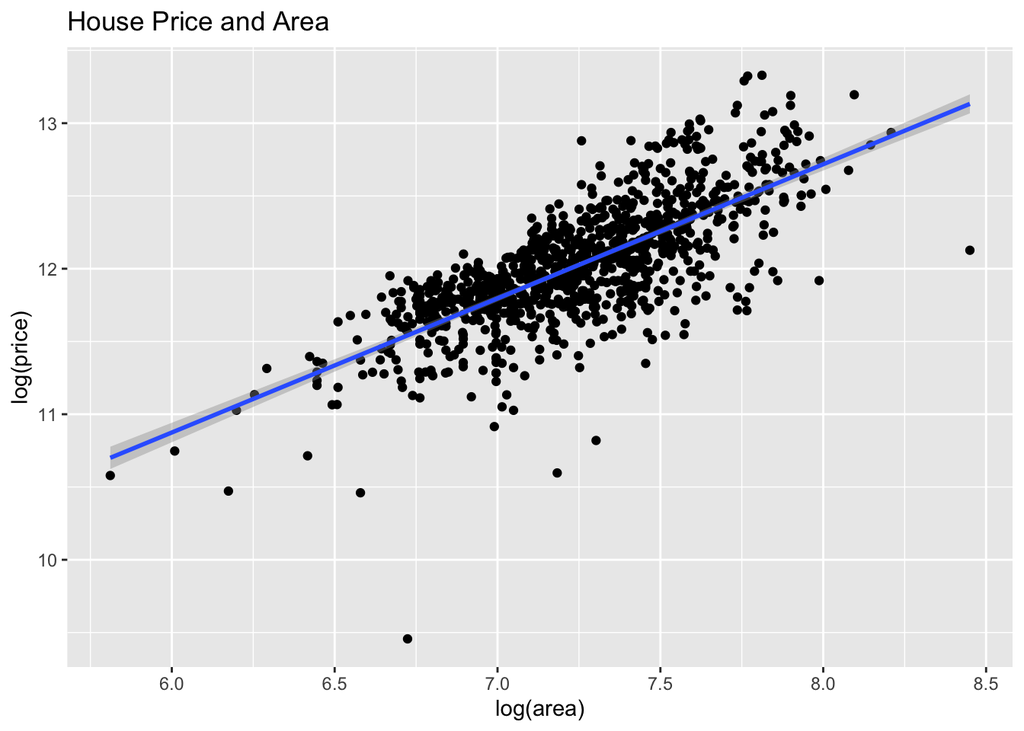

```r
ggplot(ames_train, aes(x = log(area), y = log(price))) + geom_jitter() + geom_smooth(method = "lm") + labs(title = "House Price and Area")
```

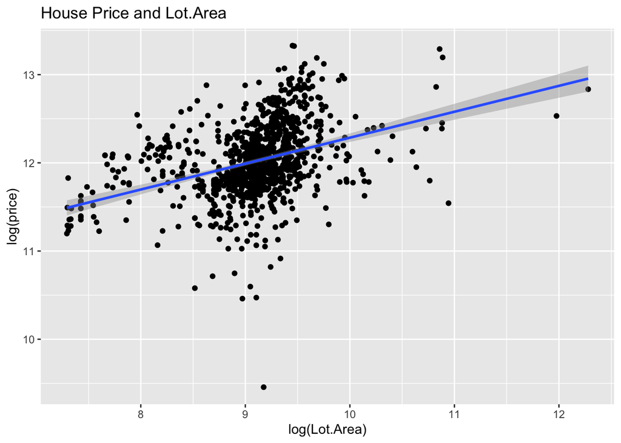

```r
ggplot(ames_train, aes(x = log(Lot.Area), y = log(price))) + geom_jitter() + geom_smooth(method = "lm") + labs(title = "House Price and Lot.Area")
```

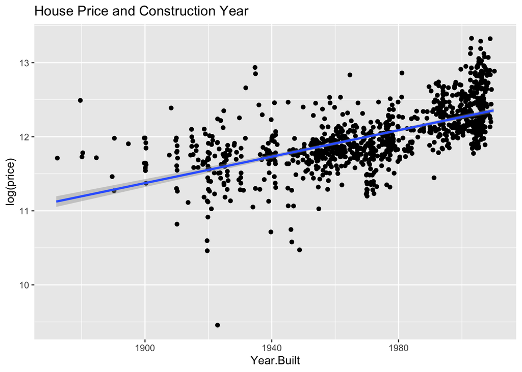

```r
ggplot(ames_train, aes(x = Year.Built, y = log(price))) + geom_jitter() + geom_smooth(method = "lm") + labs(title = "House Price and Construction Year")
```

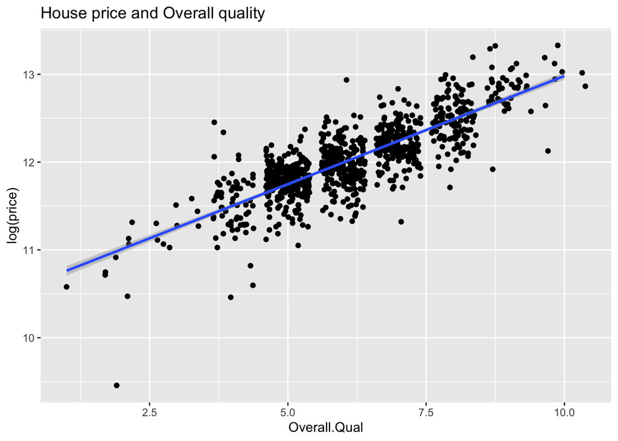

```r
ggplot(ames_train, aes(x = Overall.Qual, y = log(price))) + geom_jitter() + geom_smooth(method = "lm") + labs(title = "House price and Overall quality")
```

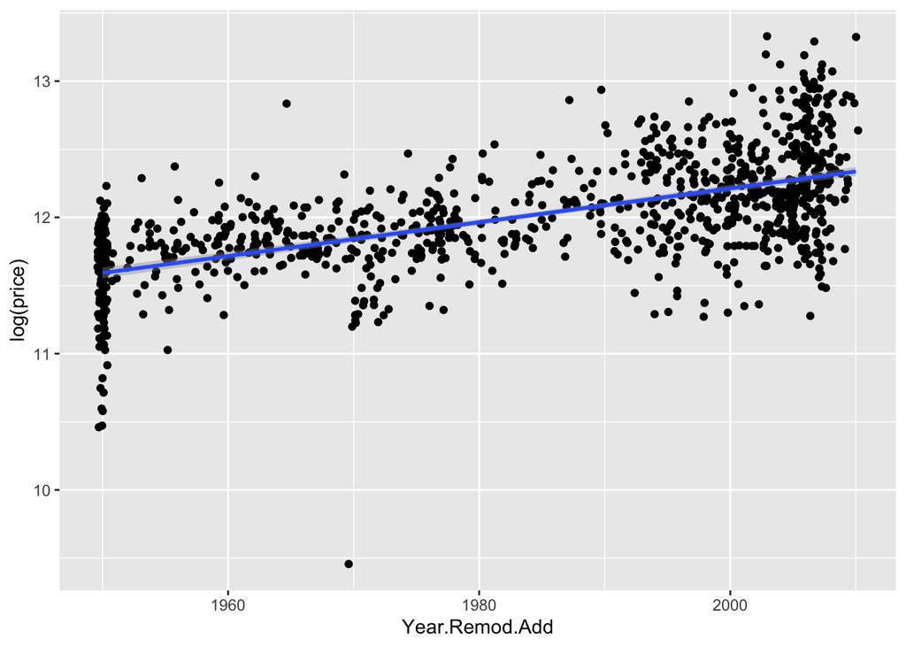

```r
ggplot(ames_train, aes(x = Year.Remod.Add, y = log(price))) + geom_jitter() + geom_smooth(method = "lm")
```

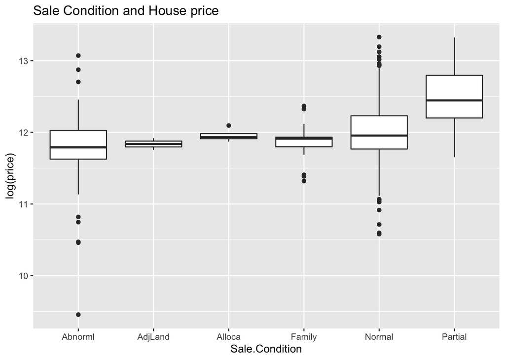

```r
ggplot(ames_train, aes(x = Sale.Condition, y = log(price))) + geom_boxplot() + labs(title = "Sale Condition and House price")
```

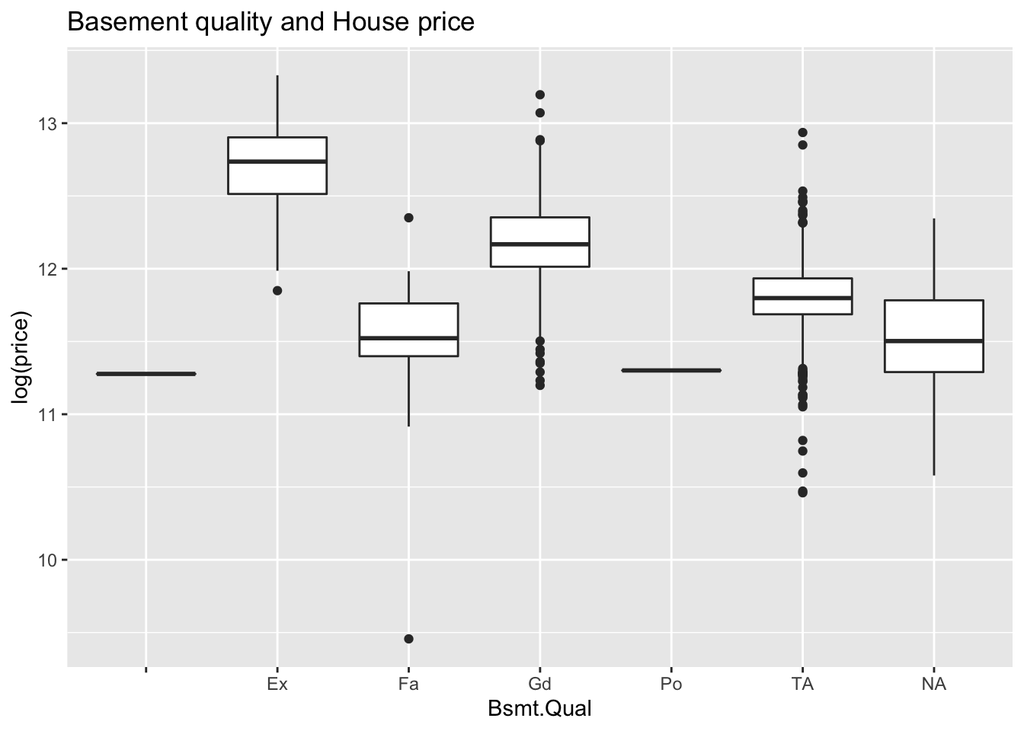

```r
ggplot(ames_train, aes(x = Bsmt.Qual, y = log(price))) + geom_boxplot() + labs(title = "Basement quality and House price")
```

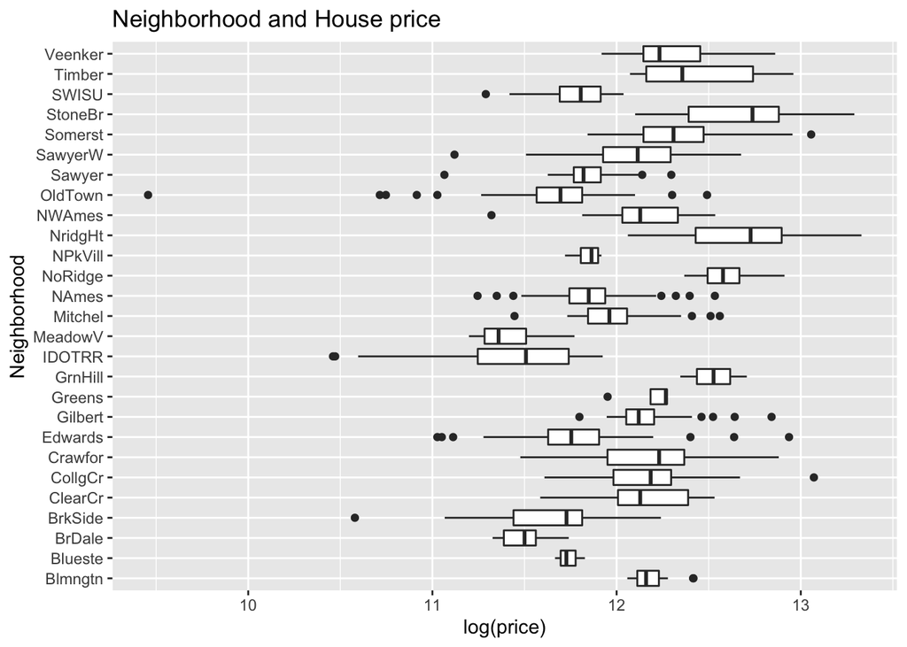

```r
ggplot(ames_train, aes(x = Neighborhood, y = log(price))) + geom_boxplot() + labs(title = "Neighborhood and House price") + coord_flip()
```

Since the main purpose of this research is to find undervalued houses, it is meaningful to examine the explanatory variables that are correlated with the response variable price. As graphs shown above, continuous variables log(area), Year.Built, Year.Remod.Add, Overall.Qual all have a strong linear relationship with variable log(price).

As for categorical variables, we can also see location(Neighborhood), sale condition and basement quality can affect house prices. For example NridgHT, StoneBr are the most expensive neighborhoods, while IDOTRR is among the least expensive ones. Houses with sale condition Partial tend to sell higher prices, basement.Qual Excellent may also arise sell price.

## 2.2 Part 2 - Development and assessment of an initial model, following a semi-guided process of analysis

### 2.2.1 Section 2.1 An Initial Model

In building a model, it is often useful to start by creating a simple, intuitive initial model based on the results of the exploratory data analysis. (Note: The goal at this stage is **not** to identify the “best” possible model but rather to choose a reasonable and understandable starting point. Later you will expand and revise this model to create your final model.

Based on your EDA, select *at most* 10 predictor variables from “ames_train” and create a linear model for `price` (or a transformed version of price) using those variables. Provide the *R code* and the *summary output table* for your model, a *brief justification* for the variables you have chosen, and a *brief discussion* of the model results in context (focused on the variables that appear to be important predictors and how they relate to sales price).

NOTE: Write your written response to section 2.1 here. Delete this note before you submit your work.

```r
colSums(is.na(ames_train))
```

```
##             PID            area           price     MS.SubClass       MS.Zoning
##               0               0               0               0               0
##    Lot.Frontage        Lot.Area          Street           Alley       Lot.Shape
##             167               0               0             933               0
##    Land.Contour       Utilities      Lot.Config      Land.Slope    Neighborhood
##               0               0               0               0               0
##     Condition.1     Condition.2       Bldg.Type     House.Style    Overall.Qual
##               0               0               0               0               0
##    Overall.Cond      Year.Built  Year.Remod.Add      Roof.Style       Roof.Matl
##               0               0               0               0               0
##    Exterior.1st    Exterior.2nd    Mas.Vnr.Type    Mas.Vnr.Area      Exter.Qual
##               0               0               0               7               0
##      Exter.Cond      Foundation       Bsmt.Qual       Bsmt.Cond   Bsmt.Exposure
##               0               0              21              21              21
##  BsmtFin.Type.1    BsmtFin.SF.1  BsmtFin.Type.2    BsmtFin.SF.2     Bsmt.Unf.SF
##              21               1              21               1               1
##   Total.Bsmt.SF         Heating      Heating.QC     Central.Air      Electrical
##               1               0               0               0               0
##     X1st.Flr.SF     X2nd.Flr.SF Low.Qual.Fin.SF  Bsmt.Full.Bath  Bsmt.Half.Bath
##               0               0               0               1               1
##       Full.Bath       Half.Bath   Bedroom.AbvGr   Kitchen.AbvGr    Kitchen.Qual
##               0               0               0               0               0
##   TotRms.AbvGrd      Functional      Fireplaces    Fireplace.Qu     Garage.Type
##               0               0               0             491              46
##   Garage.Yr.Blt   Garage.Finish     Garage.Cars     Garage.Area     Garage.Qual
##              48              46               1               1              47
##     Garage.Cond     Paved.Drive    Wood.Deck.SF   Open.Porch.SF  Enclosed.Porch
##              47               0               0               0               0
##     X3Ssn.Porch    Screen.Porch       Pool.Area         Pool.QC           Fence
##               0               0               0             997             798
##    Misc.Feature        Misc.Val         Mo.Sold         Yr.Sold       Sale.Type
##             971               0               0               0               0
##  Sale.Condition
##               0
```

```r
start <- lm(log(price) ~ log(area) + log(Lot.Area) + Overall.Qual +  Overall.Cond + Year.Built +  Land.Slope+ Neighborhood + Bldg.Type + Bedroom.AbvGr + X1st.Flr.SF, data=ames_train)

summary(start)
```

```
##
## Call:
## lm(formula = log(price) ~ log(area) + log(Lot.Area) + Overall.Qual +
##     Overall.Cond + Year.Built + Land.Slope + Neighborhood + Bldg.Type +
##     Bedroom.AbvGr + X1st.Flr.SF, data = ames_train)
##
## Residuals:
##      Min       1Q   Median       3Q      Max
## -1.46755 -0.06678  0.00381  0.07793  0.47861
##
## Coefficients:
##                       Estimate Std. Error t value Pr(>|t|)
## (Intercept)         -2.041e+00  7.966e-01  -2.562 0.010561 *
## log(area)            4.699e-01  2.732e-02  17.199  < 2e-16 ***
## log(Lot.Area)        8.159e-02  1.628e-02   5.011 6.44e-07 ***
## Overall.Qual         7.483e-02  6.222e-03  12.027  < 2e-16 ***
## Overall.Cond         7.244e-02  4.778e-03  15.160  < 2e-16 ***
## Year.Built           4.595e-03  3.721e-04  12.349  < 2e-16 ***
## Land.SlopeMod        4.896e-02  2.670e-02   1.833 0.067046 .
## Land.SlopeSev        1.871e-02  7.208e-02   0.260 0.795236
## NeighborhoodBlueste  9.201e-03  9.607e-02   0.096 0.923721
## NeighborhoodBrDale  -8.689e-02  6.997e-02  -1.242 0.214611
## NeighborhoodBrkSide -4.551e-02  5.727e-02  -0.795 0.427004
## NeighborhoodClearCr  2.552e-03  6.651e-02   0.038 0.969403
## NeighborhoodCollgCr -5.843e-02  4.968e-02  -1.176 0.239851
## NeighborhoodCrawfor  6.808e-02  5.669e-02   1.201 0.230112
## NeighborhoodEdwards -1.089e-01  5.189e-02  -2.099 0.036039 *
## NeighborhoodGilbert -8.222e-02  5.256e-02  -1.564 0.118108
## NeighborhoodGreens   1.565e-01  8.525e-02   1.836 0.066731 .
## NeighborhoodGrnHill  3.270e-01  1.111e-01   2.943 0.003329 **
## NeighborhoodIDOTRR  -1.822e-01  5.851e-02  -3.114 0.001903 **
## NeighborhoodMeadowV -1.032e-01  6.005e-02  -1.718 0.086075 .
## NeighborhoodMitchel -3.799e-02  5.273e-02  -0.720 0.471416
## NeighborhoodNAmes   -5.593e-02  5.070e-02  -1.103 0.270272
## NeighborhoodNoRidge  5.176e-02  5.470e-02   0.946 0.344252
## NeighborhoodNPkVill  4.278e-02  8.729e-02   0.490 0.624218
## NeighborhoodNridgHt  1.078e-01  4.992e-02   2.159 0.031128 *
## NeighborhoodNWAmes  -1.214e-01  5.297e-02  -2.291 0.022179 *
## NeighborhoodOldTown -1.085e-01  5.728e-02  -1.894 0.058556 .
## NeighborhoodSawyer  -4.857e-02  5.274e-02  -0.921 0.357250
## NeighborhoodSawyerW -1.060e-01  5.165e-02  -2.052 0.040394 *
## NeighborhoodSomerst  3.159e-02  4.810e-02   0.657 0.511457
## NeighborhoodStoneBr  1.553e-01  5.585e-02   2.780 0.005539 **
## NeighborhoodSWISU   -2.077e-02  6.690e-02  -0.311 0.756246
## NeighborhoodTimber  -2.054e-03  5.745e-02  -0.036 0.971484
## NeighborhoodVeenker -5.184e-02  6.595e-02  -0.786 0.432064
## Bldg.Type2fmCon      3.678e-02  3.426e-02   1.074 0.283220
## Bldg.TypeDuplex     -1.074e-01  2.694e-02  -3.988 7.17e-05 ***
## Bldg.TypeTwnhs      -1.255e-01  3.754e-02  -3.344 0.000858 ***
## Bldg.TypeTwnhsE     -6.473e-02  2.400e-02  -2.698 0.007107 **
## Bedroom.AbvGr       -3.408e-02  8.284e-03  -4.114 4.23e-05 ***
## X1st.Flr.SF          1.225e-04  1.871e-05   6.547 9.53e-11 ***
## ---
## Signif. codes:  0 '***' 0.001 '**' 0.01 '*' 0.05 '.' 0.1 ' ' 1
##
## Residual standard error: 0.1426 on 960 degrees of freedom
## Multiple R-squared:  0.8895, Adjusted R-squared:  0.885
## F-statistic: 198.2 on 39 and 960 DF,  p-value: < 2.2e-16
```

### 2.2.2 Section 2.2 Model Selection

Now either using `BAS` another stepwise selection procedure choose the “best” model you can, using your initial model as your starting point. Try at least two different model selection methods and compare their results. Do they both arrive at the same model or do they disagree? What do you think this means?

NOTE: Write your written response to section 2.2 here. Delete this note before you submit your work.

```r
start.bas <- bas.lm(log(price) ~ log(area) + log(Lot.Area) + Overall.Qual +  Overall.Cond + Year.Built +  Land.Slope+ Neighborhood + Bldg.Type + Bedroom.AbvGr + X1st.Flr.SF, data=ames_train, prior = "BIC", modelprior = uniform())

model.HPM <- predict(start.bas, ames_train, estimator = "HPM", prediction = TRUE,
                    se.fit = TRUE)

model.HPM$best.vars
```

```
##  [1] "Intercept"           "log(area)"           "log(Lot.Area)"
##  [4] "Overall.Qual"        "Overall.Cond"        "Year.Built"
##  [7] "NeighborhoodCrawfor" "NeighborhoodGrnHill" "NeighborhoodIDOTRR"
## [10] "NeighborhoodNoRidge" "NeighborhoodNridgHt" "NeighborhoodNWAmes"
## [13] "NeighborhoodSomerst" "NeighborhoodStoneBr" "Bldg.TypeDuplex"
## [16] "Bedroom.AbvGr"       "X1st.Flr.SF"
```

```r
model.BIC <- stepAIC(start, k=log(nrow(ames_train)))
```

```
## Start:  AIC=-3659.89
## log(price) ~ log(area) + log(Lot.Area) + Overall.Qual + Overall.Cond +
##     Year.Built + Land.Slope + Neighborhood + Bldg.Type + Bedroom.AbvGr +
##     X1st.Flr.SF
##
##                 Df Sum of Sq    RSS     AIC
## - Neighborhood  26    3.3064 22.829 -3683.0
## - Land.Slope     2    0.0687 19.591 -3670.2
## <none>                       19.522 -3659.9
## - Bldg.Type      4    0.6039 20.126 -3657.1
## - Bedroom.AbvGr  1    0.3441 19.866 -3649.3
## - log(Lot.Area)  1    0.5107 20.033 -3641.0
## - X1st.Flr.SF    1    0.8717 20.394 -3623.1
## - Overall.Qual   1    2.9417 22.464 -3526.4
## - Year.Built     1    3.1011 22.623 -3519.4
## - Overall.Cond   1    4.6736 24.196 -3452.2
## - log(area)      1    6.0156 25.538 -3398.2
##
## Step:  AIC=-3683.03
## log(price) ~ log(area) + log(Lot.Area) + Overall.Qual + Overall.Cond +
##     Year.Built + Land.Slope + Bldg.Type + Bedroom.AbvGr + X1st.Flr.SF
##
##                 Df Sum of Sq    RSS     AIC
## - Bldg.Type      4    0.4377 23.266 -3691.7
## - Land.Slope     2    0.2103 23.039 -3687.7
## <none>                       22.829 -3683.0
## - Bedroom.AbvGr  1    0.5303 23.359 -3667.0
## - log(Lot.Area)  1    0.9225 23.751 -3650.3
## - X1st.Flr.SF    1    1.6244 24.453 -3621.2
## - Overall.Cond   1    4.7711 27.600 -3500.1
## - Overall.Qual   1    6.2880 29.117 -3446.6
## - log(area)      1    6.6446 29.473 -3434.5
## - Year.Built     1    9.9282 32.757 -3328.8
##
## Step:  AIC=-3691.67
## log(price) ~ log(area) + log(Lot.Area) + Overall.Qual + Overall.Cond +
##     Year.Built + Land.Slope + Bedroom.AbvGr + X1st.Flr.SF
##
##                 Df Sum of Sq    RSS     AIC
## - Land.Slope     2    0.2288 23.495 -3695.7
## <none>                       23.266 -3691.7
## - Bedroom.AbvGr  1    0.7826 24.049 -3665.5
## - X1st.Flr.SF    1    1.4208 24.687 -3639.3
## - log(Lot.Area)  1    2.6278 25.894 -3591.6
## - Overall.Cond   1    5.0559 28.322 -3501.9
## - log(area)      1    6.7793 30.046 -3442.9
## - Overall.Qual   1    7.0055 30.272 -3435.4
## - Year.Built     1   10.0724 33.339 -3338.9
##
## Step:  AIC=-3695.7
## log(price) ~ log(area) + log(Lot.Area) + Overall.Qual + Overall.Cond +
##     Year.Built + Bedroom.AbvGr + X1st.Flr.SF
##
##                 Df Sum of Sq    RSS     AIC
## <none>                       23.495 -3695.7
## - Bedroom.AbvGr  1    0.8795 24.375 -3665.9
## - X1st.Flr.SF    1    1.5480 25.043 -3638.8
## - log(Lot.Area)  1    2.9067 26.402 -3586.0
## - Overall.Cond   1    5.1050 28.600 -3506.0
## - Overall.Qual   1    6.8345 30.330 -3447.3
## - log(area)      1    6.9723 30.467 -3442.7
## - Year.Built     1   10.1140 33.609 -3344.6
```

```r
model.AIC <- stepAIC(start, k=2)
```

```
## Start:  AIC=-3856.2
## log(price) ~ log(area) + log(Lot.Area) + Overall.Qual + Overall.Cond +
##     Year.Built + Land.Slope + Neighborhood + Bldg.Type + Bedroom.AbvGr +
##     X1st.Flr.SF
##
##                 Df Sum of Sq    RSS     AIC
## - Land.Slope     2    0.0687 19.591 -3856.7
## <none>                       19.522 -3856.2
## - Bedroom.AbvGr  1    0.3441 19.866 -3840.7
## - Bldg.Type      4    0.6039 20.126 -3833.7
## - log(Lot.Area)  1    0.5107 20.033 -3832.4
## - X1st.Flr.SF    1    0.8717 20.394 -3814.5
## - Neighborhood  26    3.3064 22.829 -3751.7
## - Overall.Qual   1    2.9417 22.464 -3717.8
## - Year.Built     1    3.1011 22.623 -3710.8
## - Overall.Cond   1    4.6736 24.196 -3643.6
## - log(area)      1    6.0156 25.538 -3589.6
##
## Step:  AIC=-3856.69
## log(price) ~ log(area) + log(Lot.Area) + Overall.Qual + Overall.Cond +
##     Year.Built + Neighborhood + Bldg.Type + Bedroom.AbvGr + X1st.Flr.SF
##
##                 Df Sum of Sq    RSS     AIC
## <none>                       19.591 -3856.7
## - Bedroom.AbvGr  1    0.3656 19.957 -3840.2
## - Bldg.Type      4    0.6268 20.218 -3833.2
## - log(Lot.Area)  1    0.5711 20.162 -3830.0
## - X1st.Flr.SF    1    0.9257 20.517 -3812.5
## - Neighborhood  26    3.4481 23.039 -3746.6
## - Overall.Qual   1    2.8893 22.480 -3721.1
## - Year.Built     1    3.1414 22.732 -3710.0
## - Overall.Cond   1    4.7005 24.291 -3643.6
## - log(area)      1    6.0911 25.682 -3588.0
```

```r
model.BIC$anova
```

```
## Stepwise Model Path
## Analysis of Deviance Table
##
## Initial Model:
## log(price) ~ log(area) + log(Lot.Area) + Overall.Qual + Overall.Cond +
##     Year.Built + Land.Slope + Neighborhood + Bldg.Type + Bedroom.AbvGr +
##     X1st.Flr.SF
##
## Final Model:
## log(price) ~ log(area) + log(Lot.Area) + Overall.Qual + Overall.Cond +
##     Year.Built + Bedroom.AbvGr + X1st.Flr.SF
##
##
##             Step Df  Deviance Resid. Df Resid. Dev       AIC
## 1                                   960   19.52232 -3659.886
## 2 - Neighborhood 26 3.3063945       986   22.82872 -3683.027
## 3    - Bldg.Type  4 0.4377387       990   23.26646 -3691.665
## 4   - Land.Slope  2 0.2287728       992   23.49523 -3695.696
```

```r
model.AIC$anova
```

```
## Stepwise Model Path
## Analysis of Deviance Table
##
## Initial Model:
## log(price) ~ log(area) + log(Lot.Area) + Overall.Qual + Overall.Cond +
##     Year.Built + Land.Slope + Neighborhood + Bldg.Type + Bedroom.AbvGr +
##     X1st.Flr.SF
##
## Final Model:
## log(price) ~ log(area) + log(Lot.Area) + Overall.Qual + Overall.Cond +
##     Year.Built + Neighborhood + Bldg.Type + Bedroom.AbvGr + X1st.Flr.SF
##
##
##           Step Df  Deviance Resid. Df Resid. Dev       AIC
## 1                                 960   19.52232 -3856.197
## 2 - Land.Slope  2 0.0686517       962   19.59098 -3856.686
```

For model selection I used BAS regression method to find the highest probability model, to address the model uncertainty, I used prior = “BIC” to approximate reference prior, and set model prior as uniform() to represent equal likelihood for each model.

For the second method I used AIC, BIC as criterion to conduct stepwise selection on my initial frequentest regression model. BIC model exclude three variables Neighborhood, Bldg.Type and Land.Slope. AIC model exclude only Land.Slope from the initial model. * * *

### 2.2.3 Section 2.3 Initial Model Residuals

One way to assess the performance of a model is to examine the model’s residuals. In the space below, create a residual plot for your preferred model from above and use it to assess whether your model appears to fit the data well. Comment on any interesting structure in the residual plot (trend, outliers, etc.) and briefly discuss potential implications it may have for your model and inference / prediction you might produce.

NOTE: Write your written response to section 2.3 here. Delete this note before you submit your work.

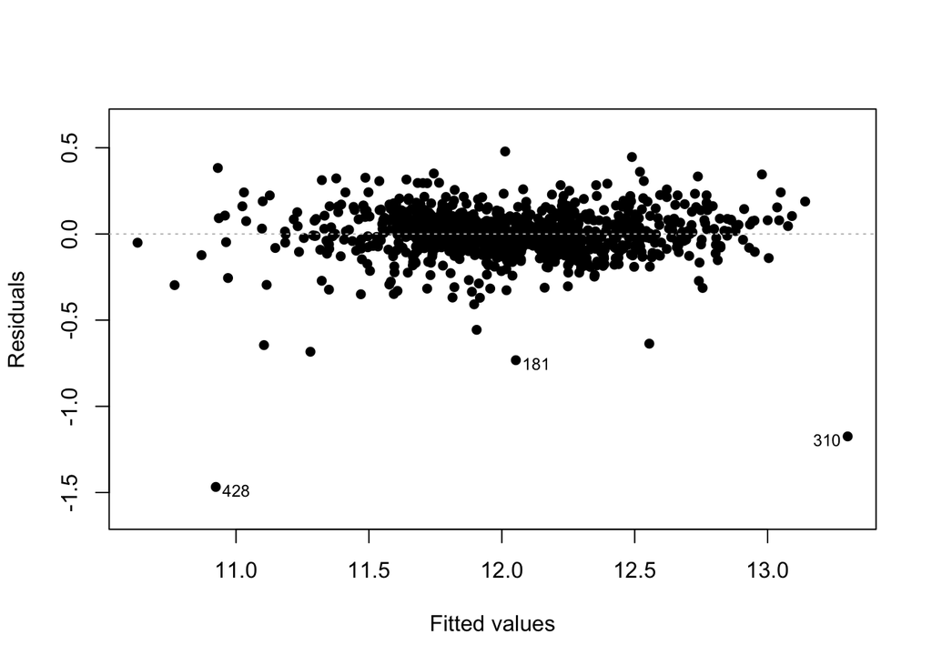

```r
plot(start, which = 1, add.smooth = F, ask = F, pch = 16, sub.caption = "", caption = "")
```

It is shown that residuals are randomly plotted around 0 against fitted values, there are three outliers, which are house 428, 181 and 310. The model tends to overestimate sale prices for the most expensive houses, and sale prices presenting larger variance for the least expensive houses.

### 2.2.4 Section 2.4 Initial Model RMSE

You can calculate it directly based on the model output. Be specific about the units of your RMSE (depending on whether you transformed your response variable). The value you report will be more meaningful if it is in the original units (dollars).

NOTE: Write your written response to section 2.4 here. Delete this note before you submit your work.

```r
start.rmse <- sqrt(mean((exp(start$fitted.values) - ames_train$price)^2))

start.rmse
```

```
## [1] 28046.29
```

```r
BIC.rmse <- sqrt(mean((exp(model.BIC$fitted.values) - ames_train$price)^2))

BIC.rmse
```

```
## [1] 33057.06
```

```r
AIC.rmse <- sqrt(mean((exp(model.AIC$fitted.values) - ames_train$price)^2))

AIC.rmse
```

```
## [1] 28266.66
```

```r
HPM.rmse <- sqrt(mean((exp(model.HPM$fit) - ames_train$price)^2))

HPM.rmse
```

```
## [1] 29458.3
```

```r
#removing outliers

normal_train <- ames_train[-c(428, 181, 310),]

start2 <- lm(log(price) ~ log(area) + log(Lot.Area) + Overall.Qual +  Overall.Cond + Year.Built +  Land.Slope+ Neighborhood + Bldg.Type + Bedroom.AbvGr + X1st.Flr.SF, data = normal_train)

model.BIC2 <- stepAIC(start2, k=log(nrow(normal_train)))
```

```
## Start:  AIC=-3892.67
## log(price) ~ log(area) + log(Lot.Area) + Overall.Qual + Overall.Cond +
##     Year.Built + Land.Slope + Neighborhood + Bldg.Type + Bedroom.AbvGr +
##     X1st.Flr.SF
##
##                 Df Sum of Sq    RSS     AIC
## - Neighborhood  26    2.7687 18.000 -3905.7
## - Land.Slope     2    0.0419 15.273 -3903.7
## <none>                       15.231 -3892.7
## - Bldg.Type      4    0.5925 15.824 -3882.2
## - Bedroom.AbvGr  1    0.4025 15.634 -3873.6
## - log(Lot.Area)  1    0.6926 15.924 -3855.2
## - X1st.Flr.SF    1    1.1922 16.423 -3824.4
## - Overall.Qual   1    2.8514 18.083 -3728.5
## - Year.Built     1    3.4492 18.680 -3696.1
## - Overall.Cond   1    3.8130 19.044 -3676.8
## - log(area)      1    6.0291 21.260 -3567.1
##
## Step:  AIC=-3905.67
## log(price) ~ log(area) + log(Lot.Area) + Overall.Qual + Overall.Cond +
##     Year.Built + Land.Slope + Bldg.Type + Bedroom.AbvGr + X1st.Flr.SF
##
##                 Df Sum of Sq    RSS     AIC
## - Land.Slope     2    0.1463 18.146 -3911.4
## - Bldg.Type      4    0.4730 18.473 -3907.4
## <none>                       18.000 -3905.7
## - Bedroom.AbvGr  1    0.6312 18.631 -3878.2
## - log(Lot.Area)  1    1.0543 19.054 -3855.8
## - X1st.Flr.SF    1    2.0666 20.067 -3804.2
## - Overall.Cond   1    3.9554 21.955 -3714.5
## - Overall.Qual   1    5.8919 23.892 -3630.3
## - log(area)      1    6.8428 24.843 -3591.3
## - Year.Built     1    9.2421 27.242 -3499.4
##
## Step:  AIC=-3911.41
## log(price) ~ log(area) + log(Lot.Area) + Overall.Qual + Overall.Cond +
##     Year.Built + Bldg.Type + Bedroom.AbvGr + X1st.Flr.SF
##
##                 Df Sum of Sq    RSS     AIC
## - Bldg.Type      4    0.4929 18.639 -3912.3
## <none>                       18.146 -3911.4
## - Bedroom.AbvGr  1    0.6801 18.826 -3881.6
## - log(Lot.Area)  1    1.2432 19.390 -3852.2
## - X1st.Flr.SF    1    2.2069 20.353 -3803.9
## - Overall.Cond   1    3.9993 22.146 -3719.7
## - Overall.Qual   1    5.7704 23.917 -3643.0
## - log(area)      1    6.9595 25.106 -3594.7
## - Year.Built     1    9.2668 27.413 -3507.0
##
## Step:  AIC=-3912.31
## log(price) ~ log(area) + log(Lot.Area) + Overall.Qual + Overall.Cond +
##     Year.Built + Bedroom.AbvGr + X1st.Flr.SF
##
##                 Df Sum of Sq    RSS     AIC
## <none>                       18.639 -3912.3
## - Bedroom.AbvGr  1    1.0415 19.681 -3865.0
## - X1st.Flr.SF    1    1.9471 20.586 -3820.2
## - log(Lot.Area)  1    3.0885 21.728 -3766.4
## - Overall.Cond   1    4.2781 22.917 -3713.2
## - Overall.Qual   1    6.5008 25.140 -3620.9
## - log(area)      1    7.1906 25.830 -3593.9
## - Year.Built     1    9.4765 28.116 -3509.4
```

```r
normalised.BIC.rmse <- sqrt(mean((exp(model.BIC2$fitted.values) - normal_train$price)^2))

normalised.BIC.rmse
```

```
## [1] 26844.41
```

### 2.2.5 Section 2.5 Overfitting

The process of building a model generally involves starting with an initial model (as you have done above), identifying its shortcomings, and adapting the model accordingly. This process may be repeated several times until the model fits the data reasonably well. However, the model may do well on training data but perform poorly out-of-sample (meaning, on a dataset other than the original training data) because the model is overly-tuned to specifically fit the training data. This is called “overfitting.” To determine whether overfitting is occurring on a model, compare the performance of a model on both in-sample and out-of-sample data sets. To look at performance of your initial model on out-of-sample data, you will use the data set `ames_test`.

```r
load("ames_test.Rdata")
```

Use your model from above to generate predictions for the housing prices in the test data set. Are the predictions significantly more accurate (compared to the actual sales prices) for the training data than the test data? Why or why not? Briefly explain how you determined that (what steps or processes did you use)?

NOTE: Write your written response to section 2.5 here. Delete this note before you submit your work.

```r
pred.BIC <- exp(predict(model.BIC, ames_test))

test.BIC.rmse <- sqrt(mean((pred.BIC - ames_test$price)^2))

test.BIC.rmse
```

```
## [1] 24601.05
```

It is shown that BIC model on test data have lower rmse value than on train data.

**Note to the learner:** If in real-life practice this out-of-sample analysis shows evidence that the training data fits your model a lot better than the test data, it is probably a good idea to go back and revise the model (usually by simplifying the model) to reduce this overfitting. For simplicity, we do not ask you to do this on the assignment, however.

## 2.3 Part 3 Development of a Final Model

Now that you have developed an initial model to use as a baseline, create a final model with *at most* 20 variables to predict housing prices in Ames, IA, selecting from the full array of variables in the dataset and using any of the tools that we introduced in this specialization.

Carefully document the process that you used to come up with your final model, so that you can answer the questions below.

### 2.3.1 Section 3.1 Final Model

Provide the summary table for your model.

NOTE: Write your written response to section 3.1 here. Delete this note before you submit your work.

```r
final <- lm(log(price) ~ log(area) + log(Lot.Area) + Overall.Qual +  Overall.Cond + Year.Built + Land.Slope + Year.Remod.Add + MS.Zoning + Land.Contour + Neighborhood + Bldg.Type + Bedroom.AbvGr + log(X1st.Flr.SF) + Central.Air + Wood.Deck.SF + Paved.Drive + Fireplaces + Bsmt.Qual, data = normal_train)

summary(final)
```

```
##
## Call:
## lm(formula = log(price) ~ log(area) + log(Lot.Area) + Overall.Qual +
##     Overall.Cond + Year.Built + Land.Slope + Year.Remod.Add +
##     MS.Zoning + Land.Contour + Neighborhood + Bldg.Type + Bedroom.AbvGr +
##     log(X1st.Flr.SF) + Central.Air + Wood.Deck.SF + Paved.Drive +
##     Fireplaces + Bsmt.Qual, data = normal_train)
##
## Residuals:
##      Min       1Q   Median       3Q      Max
## -0.59222 -0.06572  0.00427  0.06820  0.47895
##
## Coefficients:
##                       Estimate Std. Error t value Pr(>|t|)
## (Intercept)         -3.923e+00  8.715e-01  -4.501 7.62e-06 ***
## log(area)            4.220e-01  2.464e-02  17.126  < 2e-16 ***
## log(Lot.Area)        7.897e-02  1.432e-02   5.515 4.54e-08 ***
## Overall.Qual         6.026e-02  5.506e-03  10.944  < 2e-16 ***
## Overall.Cond         5.324e-02  4.762e-03  11.179  < 2e-16 ***
## Year.Built           4.012e-03  3.840e-04  10.448  < 2e-16 ***
## Land.SlopeMod        1.540e-02  2.468e-02   0.624 0.532820
## Land.SlopeSev       -1.303e-02  6.266e-02  -0.208 0.835344
## Year.Remod.Add       9.527e-04  3.023e-04   3.152 0.001676 **
## MS.ZoningFV          3.188e-01  6.175e-02   5.162 3.00e-07 ***
## MS.ZoningI (all)     2.664e-01  1.331e-01   2.002 0.045546 *
## MS.ZoningRH          2.869e-01  7.230e-02   3.968 7.81e-05 ***
## MS.ZoningRL          3.278e-01  5.256e-02   6.238 6.76e-10 ***
## MS.ZoningRM          2.806e-01  4.796e-02   5.851 6.80e-09 ***
## Land.ContourHLS     -1.657e-03  3.048e-02  -0.054 0.956660
## Land.ContourLow      2.562e-02  4.178e-02   0.613 0.539914
## Land.ContourLvl     -1.188e-02  2.364e-02  -0.502 0.615487
## NeighborhoodBlueste  7.347e-02  8.253e-02   0.890 0.373619
## NeighborhoodBrDale   2.158e-02  6.284e-02   0.343 0.731337
## NeighborhoodBrkSide  7.680e-02  5.237e-02   1.466 0.142881
## NeighborhoodClearCr  2.293e-02  5.612e-02   0.409 0.682880
## NeighborhoodCollgCr -1.547e-02  4.148e-02  -0.373 0.709241
## NeighborhoodCrawfor  1.270e-01  4.858e-02   2.615 0.009067 **
## NeighborhoodEdwards -2.428e-02  4.422e-02  -0.549 0.583091
## NeighborhoodGilbert -5.291e-02  4.384e-02  -1.207 0.227827
## NeighborhoodGreens   1.398e-01  7.076e-02   1.976 0.048499 *
```

[output cut: 25 more lines]

```
## Paved.DriveP        -2.673e-02  2.920e-02  -0.916 0.360166
## Paved.DriveY         9.351e-03  2.083e-02   0.449 0.653524
## Fireplaces           2.953e-02  7.736e-03   3.818 0.000144 ***
## Bsmt.QualEx          4.662e-01  1.217e-01   3.832 0.000136 ***
## Bsmt.QualFa          3.153e-01  1.217e-01   2.591 0.009734 **
## Bsmt.QualGd          3.481e-01  1.203e-01   2.894 0.003894 **
## Bsmt.QualPo          5.418e-01  1.740e-01   3.114 0.001902 **
## Bsmt.QualTA          3.276e-01  1.195e-01   2.741 0.006239 **
## ---
## Signif. codes:  0 '***' 0.001 '**' 0.01 '*' 0.05 '.' 0.1 ' ' 1
##
## Residual standard error: 0.117 on 917 degrees of freedom
##   (21 observations deleted due to missingness)
## Multiple R-squared:  0.9214, Adjusted R-squared:  0.9165
## F-statistic: 185.4 on 58 and 917 DF,  p-value: < 2.2e-16
```

The final model is determined by initial model, which is BIC model. Then I used forward selection method to add more predictors for the final model, which have higher adjusted r value.

### 2.3.2 Section 3.2 Transformation

Did you decide to transform any variables? Why or why not? Explain in a few sentences.

NOTE: Write your written response to section 3.2 here. Delete this note before you submit your work.

### 2.3.3 Section 3.3 Variable Interaction

Did you decide to include any variable interactions? Why or why not? Explain in a few sentences.

NOTE: Write your written response to section 3.3 here. Delete this note before you submit your work.

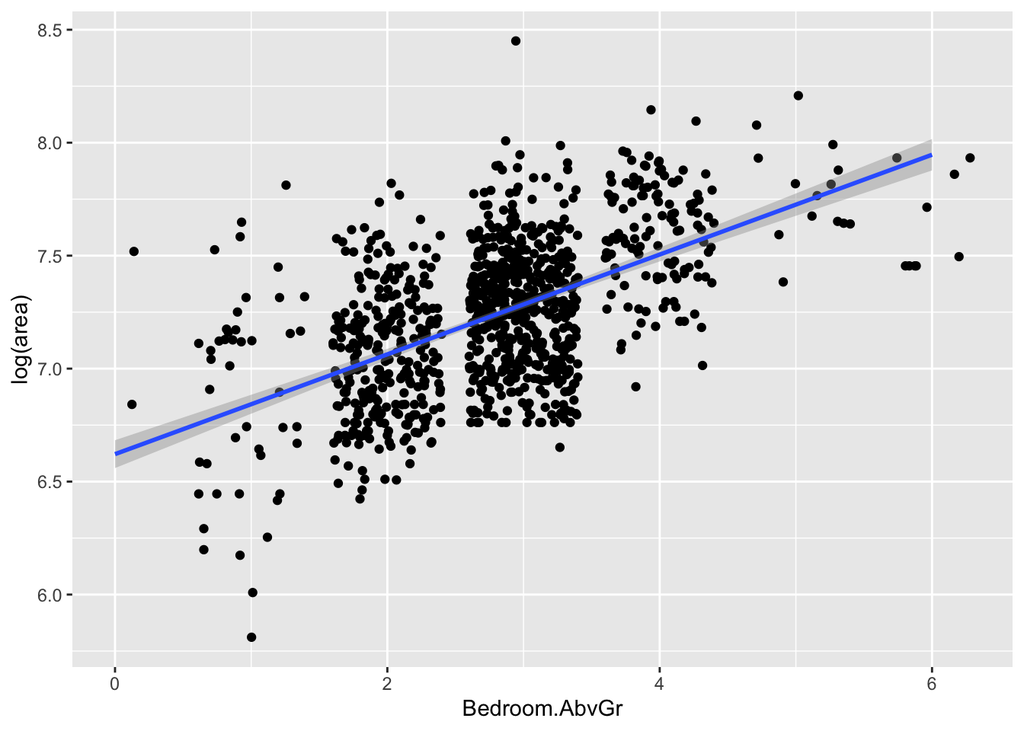

```r
ggplot(ames_train, aes(x = Bedroom.AbvGr , y = log(area))) + geom_jitter() + geom_smooth(method = "lm")
```

### 2.3.4 Section 3.4 Variable Selection

What method did you use to select the variables you included? Why did you select the method you used? Explain in a few sentences.

NOTE: Write your written response to section 3.4 here. Delete this note before you submit your work.

I used forward selection method to choose more predictors for the final model with higher adjusted-r value.

### 2.3.5 Section 3.5 Model Testing

How did testing the model on out-of-sample data affect whether or how you changed your model? Explain in a few sentences.

NOTE: Write your written response to section 3.5 here. Delete this note before you submit your work.

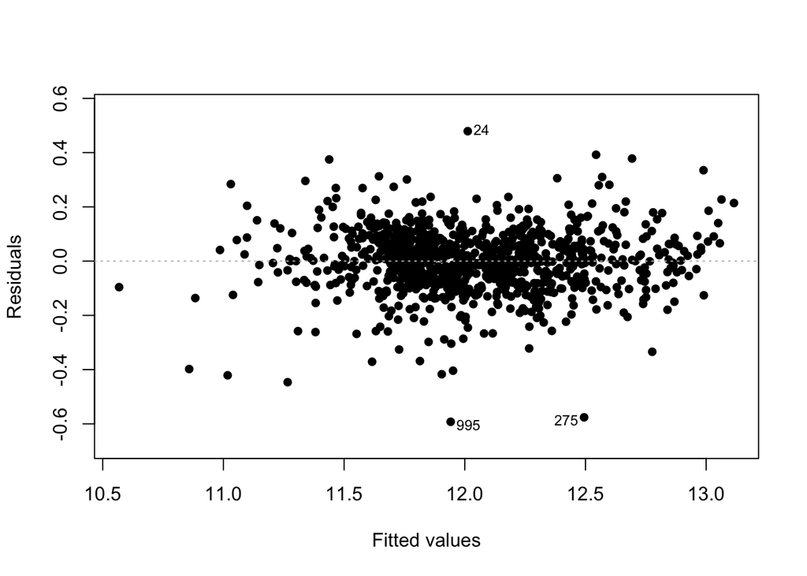

```r
ames_test <- normal_train %>% filter(Neighborhood != "Landmrk")

plot(final, which = 1, add.smooth = F, ask = F, pch = 16, sub.caption = "", caption = "")
```

```r
pred.final <- exp(predict(final, ames_test))

resid <- na.omit(ames_test$price - pred.final)

rmse.final <- sqrt(mean(resid^2))

rmse.final
```

```
## [1] 23165.79
```

## 2.4 Part 4 Final Model Assessment

### 2.4.1 Section 4.1 Final Model Residual

For your final model, create and briefly interpret an informative plot of the residuals.

Residual plot is shown above, the residuals are also distributed condensedly around 0, which means the model is a good fit.

NOTE: Write your written response to section 4.1 here. Delete this note before you submit your work.

### 2.4.2 Section 4.2 Final Model RMSE

For your final model, calculate and briefly comment on the RMSE.

NOTE: Write your written response to section 4.2 here. Delete this note before you submit your work.

### 2.4.3 Section 4.3 Final Model Evaluation

What are some strengths and weaknesses of your model?

As we can see from the summary, the final model has very small p-value < 2.2e-16, and very high adjusted R2 value 0.9165, also smaller RMSE value, which means my final model is a good fit.

The weaknesses are potential bias when data are normalized, and there is no trade-off for the selection of predcitors for acheiving a more parsimonous model.

NOTE: Write your written response to section 4.3 here. Delete this note before you submit your work.

### 2.4.4 Section 4.4 Final Model Validation

Testing your final model on a separate, validation data set is a great way to determine how your model will perform in real-life practice.

You will use the “ames_validation” dataset to do some additional assessment of your final model. Discuss your findings, be sure to mention: * What is the RMSE of your final model when applied to the validation data?  
* How does this value compare to that of the training data and/or testing data? * What percentage of the 95% predictive confidence (or credible) intervals contain the true price of the house in the validation data set?  
* From this result, does your final model properly reflect uncertainty?

```r
load("/Users/personalfile/Downloads/_10a3d7dd8d7090e91d1e9722482a5c33_ames_validation.Rdata")
```

NOTE: Write your written response to section 4.4 here. Delete this note before you submit your work.

```r
ames_validation_normalised <- ames_validation %>% filter(MS.Zoning != "A (agr)")

valid.final <- exp(predict(final, ames_validation_normalised))

resid <- na.omit(ames_validation_normalised$price - valid.final)

rmse.final.valid <- sqrt(mean(resid^2))

rmse.final.valid
```

```
## [1] 21192.82
```

```r
pred.full.final <- exp(predict(final, ames_validation_normalised, interval = "prediction"))

coverage_prob <- mean(ames_validation_normalised$price > pred.full.final[,"lwr"] & ames_validation_normalised$price < pred.full.final[,"upr"])
```

## 2.5 Part 5 Conclusion

Provide a brief summary of your results, and a brief discussion of what you have learned about the data and your model.